# This is How to Randomly Generate Album Cover in 5 Easy Steps using Python and Jupyter Notebook

### The purpose of this article is to demonstrate how to create randomly generated album cover using Python and Jupyter Notebook. The following is a summary of the steps used.

1. Defining the required libraries
2. Defining and learn how to use the display_cover function
3. Using Wikipedia to load a random page
4. Extracting the album and band titles from the page
5. Displaying the generated album cover

## 1. Importing the Required Libraries

```python
from IPython.display import Image as IPythonImage
from PIL import Image
from PIL import ImageFont
from PIL import ImageDraw
```

## 2. Defining and Learn How to Use the display_cover Function

```python
def display_cover(top,bottom ):
    """This fucntoin
    """
    import requests
    name='album_art_raw.png'
    # Now let's make get an album cover.
    # https://picsum.photos/ is a free service that offers random images.
    # Let's get a random image:
    album_art_raw = requests.get('https://picsum.photos/500/500/?random')
    # and save it as 'album_art_raw.png'
    with open(name,'wb') as album_art_raw_file:
       album_art_raw_file.write(album_art_raw.content)
    # Now that we have our raw image, let's open it
    # and write our band and album name on it
    img = Image.open("album_art_raw.png")
    draw = ImageDraw.Draw(img)

    # We'll choose a font for our band and album title,
    # run "% ls /usr/share/fonts/truetype/dejavu" in a cell to see what else is available,
    # or download your own .ttf fonts!
    band_name_font = ImageFont.truetype("DejaVuSans-Bold.ttf", 25) #25pt font
    album_name_font = ImageFont.truetype("DejaVuSans-Bold.ttf", 20) # 20pt font

    # the x,y coordinates for where our album name and band name text will start
    # counted from the top left of the picture (in pixels)
    band_x, band_y = 50, 50
    album_x, album_y = 50, 400

    # Our text should be visible on any image. A good way
    # of accomplishing that is to use white text with a
    # black border. We'll use the technique shown here to draw the border:
    # https://mail.python.org/pipermail/image-sig/2009-May/005681.html
    outline_color ="black"
    draw.text((band_x-1, band_y-1), top, font=band_name_font, fill=outline_color)
    draw.text((band_x+1, band_y-1), top, font=band_name_font, fill=outline_color)
    draw.text((band_x-1, band_y+1), top, font=band_name_font, fill=outline_color)
    draw.text((band_x+1, band_y+1), top, font=band_name_font, fill=outline_color)
    draw.text((album_x-1, album_y-1), bottom , font=album_name_font, fill=outline_color)
    draw.text((album_x+1, album_y-1), bottom , font=album_name_font, fill=outline_color)
    draw.text((album_x-1, album_y+1), bottom , font=album_name_font, fill=outline_color)
    draw.text((album_x+1, album_y+1), bottom , font=album_name_font, fill=outline_color)
    draw.text((band_x,band_y),top,(255,255,255),font=band_name_font)
    draw.text((album_x, album_y),bottom,(255,255,255),font=album_name_font)

    return img
```

The function will randomly select an image from https://picsum.photos/ and will superimpose two variables over the image namely top and buttom. The below code shows how to use the helper cover and generate the image. The result is shown on the top of the page.

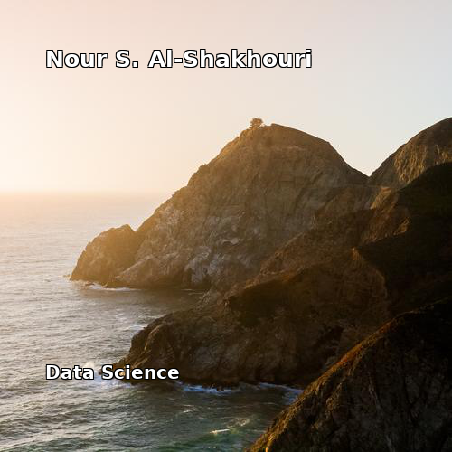

```python
# display the top and bottom text
img=display_cover(top='Nour S. Al-Shakhouri',bottom='Data Science')

# save the image file to sample-out.png
img.save('sample-out.png')

# read and display the image
IPythonImage(filename='sample-out.png')
```

## 3. Using Wikipedia to Load a Random Page

```python
# importing the requests librariy
import requests

# defining the URL to random Wikipedia page and convert to a string
wikipedia_link='https://en.wikipedia.org/wiki/Special:Random'

# use get function adn requests libaray to download the Wikipedia page
# from the wikipedia_link and assign it to raw_random_wikipedia_page as
# raw XML
raw_random_wikipedia_page = requests.get(wikipedia_link)

# use the text data attribute to extract the XML as a text file and assign
# it to page and print
page = raw_random_wikipedia_page.text
print(page)
```

[output not shown]

[output cut: 342 more lines]

[output not shown]

## 4. Extracting the Album and Band Titles from the Page

```python
# finidng the title xml tages and remove them

starttitle = page.find('<title>')
endtitle = page.find('</title>')
title = page[starttitle +7   : endtitle]
print(title)
```

```
European Climate Foundation - Wikipedia
```

```python
# remove the -Wikipedia from the title

band_title = title.replace(' - Wikipedia', '')
print(band_title)
```

```
European Climate Foundation
```

Steps 3 and 4 are repeated to create the album title. The code will be as below

```python
raw_random_wikipedia_page = requests.get(wikipedia_link)
page = raw_random_wikipedia_page.text
print(page)
```

[output not shown]

[output cut: 255 more lines]

[output not shown]

```python
starttitle = page.find('<title>')
endtitle = page.find('</title>')
title = page[starttitle + 7 : endtitle]
print(title)
```

```
Matthys du Toit - Wikipedia
```

```python
album_title = title.replace(' - Wikipedia', '')
print(album_title)
```

```
Matthys du Toit
```

Printing the band and album titles

```python
print("Your band: ", band_title)
print("Your album: ", album_title)
```

```
Your band:  European Climate Foundation
Your album:  Matthys du Toit
```

## 5. Displaying the Generated Album Cover

```python
# using the display_cover function to put the generated random title
# for the band and album names
img=display_cover(top=band_title, bottom=album_title)

# save the file to sample-out.png
img.save('sample-out.png')
```

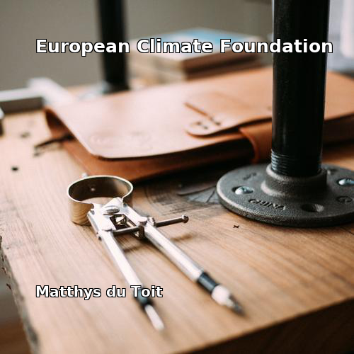

```python
# display the saved file
IPythonImage(filename='sample-out.png')
```

## Credit and Inspiration

https://picsum.photos/

https://www.coursera.org/specializations/ibm-data-science-professional-certificate

https://cognitiveclass.ai/

https://fakealbumcovers.com/

https://www.reddit.com/r/fakealbumcovers/

## License

The MIT License (MIT)

Copyright © 2019

Permission is hereby granted, free of charge, to any person obtaining a copy of this software and associated documentation files (the “Software”), to deal in the Software without restriction, including without limitation the rights to use, copy, modify, merge, publish, distribute, sublicense, and/or sell copies of the Software, and to permit persons to whom the Software is furnished to do so, subject to the following conditions:

The above copyright notice and this permission notice shall be included in all copies or substantial portions of the Software.

THE SOFTWARE IS PROVIDED “AS IS”, WITHOUT WARRANTY OF ANY KIND, EXPRESS OR IMPLIED, INCLUDING BUT NOT LIMITED TO THE WARRANTIES OF MERCHANTABILITY, FITNESS FOR A PARTICULAR PURPOSE AND NONINFRINGEMENT. IN NO EVENT SHALL THE AUTHORS OR COPYRIGHT HOLDERS BE LIABLE FOR ANY CLAIM, DAMAGES OR OTHER LIABILITY, WHETHER IN AN ACTION OF CONTRACT, TORT OR OTHERWISE, ARISING FROM, OUT OF OR IN CONNECTION WITH THE SOFTWARE OR THE USE OR OTHER DEALINGS IN THE SOFTWARE.